# Course Project - Practical Machine Learning (Coursera)

1/10/2021

## Course Project - Practical Machine Learning (Coursera)

The goal of this course project is to demonstrate the use of developed skills from the “Practical Machine Learning” course (Part of the Data Science Specialization offered by JHU through Coursera) in a practical data assessment. The dataset to be analyzed was assess by Velloso et al (2013), which assessed six individuals engaged in a series of weight lifting exercises (WLE), with several actigraphy and motor axis variables constituting the breakdown of these WLE. This accelerometer data was collected from four different locations on the participants; at the forearm, arm, belt, and on the barbell being used in the WLE. These barbell exercises were conducted correctly and incorrectly in five different ways. The dataset, as well as further details related to its collection process and the assessed variables, can be found at the following website: http://web.archive.org/web/20161224072740/http:/groupware.les.inf.puc-rio.br/har

For the purposes of this project, we were asked to use machine learning (ML) techniques in analyzing both a training and testing set, the latter of which is to be submitted in quiz format. My strategy in assessing the training dataset was to construct a primary training and testing subset, including the use of cross-validation techniques (CV), across three primary types of potential models; random forest (rf), decision-tree, and a boosted tree variant (gbm in this case). Next, I constructed prediction models for the designated “testing” subject in order to assess predictive respective accuracies of each model, selected the best performing of the three, and finally used this model to assess the bonafide “testing” set that was to be reported in the quiz. Below is the code which accomplished these aforementioned tasks.

### Download Dataset

Here, we are just downloading the dataset, checking the dimensions, making sure that all variables (besides the outcome variable, **classe**, which will be assigned as a “factor” class) are numeric/integers, and finally make a basic split between the training (comprising 70% of the data) and the testing subsets (comprising the final 30%).

```r
training_dl <- download.file("https://d396qusza40orc.cloudfront.net/predmachlearn/pml-training.csv", destfile = "pml-training.csv",mode="wb")
testing_dl <- download.file("https://d396qusza40orc.cloudfront.net/predmachlearn/pml-testing.csv", destfile = "pml-testing.csv",mode="wb")
data_training <- fread("pml-training.csv", header = T, na.strings=c("","NA"))
data_testing <- fread("pml-testing.csv", header = T, na.strings=c("","NA"))


dim(data_training)
```

```
## [1] 19622   160
```

```r
dim(data_testing)
```

```
## [1]  20 160
```

```r
str(data_training$classe)
```

```
##  chr [1:19622] "A" "A" "A" "A" "A" "A" "A" "A" "A" "A" "A" "A" "A" "A" "A" ...
```

```r
data_training$classe <- as.factor(data_training$classe)

dt <- as.data.frame(data_training)
inTrain <- createDataPartition(y=dt$classe,p=0.7, list=FALSE)
training <- data_training[inTrain,]
testing <- data_training[-inTrain,]
```

### Data cleaning, Correlation analysis

Next, ML techniques require that we have a tidy dataset comprised of full columns and rows. To assess our dataset in its crude state, we construct a table to see if there are any variables with considerable amounts of missing values.

```r
percent_na <- colMeans(is.na(training))

table(percent_na)
```

```
## percent_na
##                 0  0.97968988862197 0.979762684720099 0.979835480818228
##                60                67                 1                 1
## 0.979981073014486 0.980053869112616 0.980126665210745 0.980199461308874
##                 1                 4                 1                 6
## 0.981436994977069 0.983402489626556 0.983475285724685 0.983620877920943
##                 2                 1                 1                 2
## 0.984130450607847 0.984203246705977 0.984276042804106                 1
##                 1                 4                 2                 6
```

```r
training_cut <- filter(subset(training,select=colMeans(is.na(training))<0.75))
dim(training_cut)
```

```
## [1] 13737    60
```

From the above table, it is clear that there is a bimodal distribution in column percentages of missing data, with many comprised almost completely with missing data, and a few remainders with almost no missing data. These are the variables we want to preserve and conduct ML on, which is what we accomplished in the subsequent code.  
Next, we decided to screen for variables with virtually zero variance in their values, as these will likely not be useful to include in our ML models.

```r
nsv <- nearZeroVar(training_cut,saveMetrics=T)
nsv_remove <- nsv %>% filter(nzv==T)
nsv_remove
```

```
##            freqRatio percentUnique zeroVar  nzv
## new_window  48.23656    0.01455922   FALSE TRUE
```

From the above assessment, only one variable (**new_window**) met this threshold and was consequently removed from the dataset.  
Finally, we need to remove all time and identifier variables, as these will not be analyzable by our ML models. Columns 1-5 meet this qualification, and are therefore removed from the ML dataset.

```r
training_cut2 <- training_cut %>% select(-new_window)
table(sapply(training_cut2, class))
```

```
##
## character    factor   integer   numeric
##         2         1        29        27
```

```r
training_cut3 <- training_cut2[, -(1:5)]
dim(training_cut3)
```

```
## [1] 13737    54
```

```r
table(sapply(training_cut3, class))
```

```
##
##  factor integer numeric
##       1      26      27
```

With the above table command, we confirm that all rows in the above dataset have a “classe” designation, which suggests that this dataset can now be assessed with ML. From the dim command, we see that our original dataset with 160 variables has now been reduced to 54. Next, we want to take a brief exploratory look at the correlations between all of these variables, just to see if there is anything particularly interesting that might emerge.

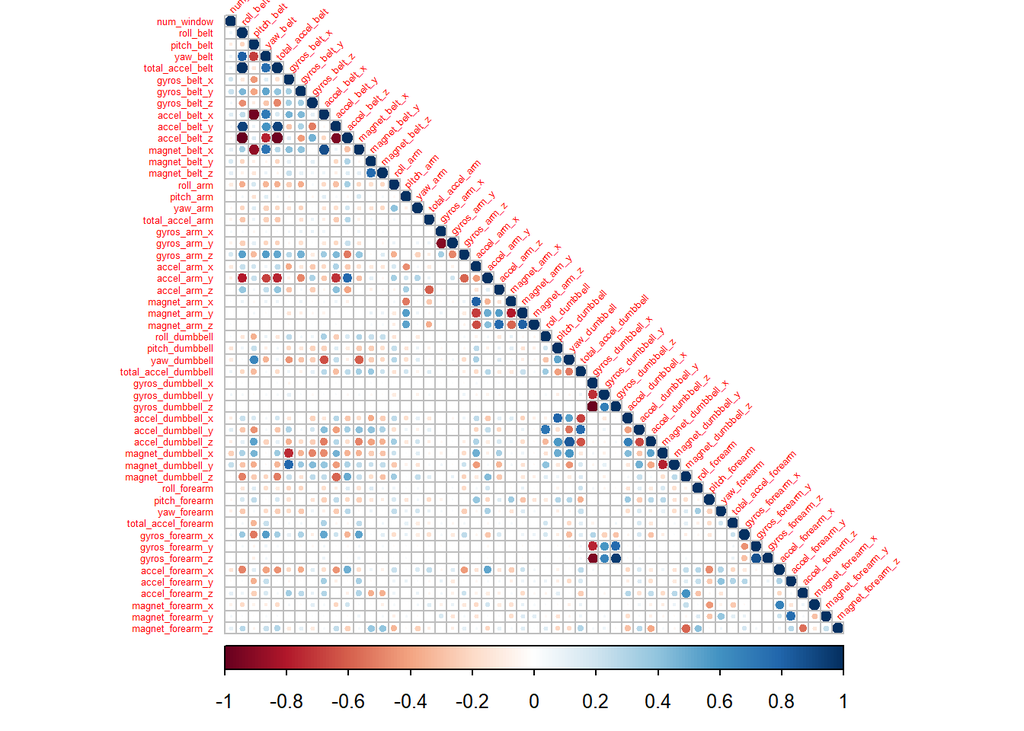

```r
covariate_matrix <- training_cut3 %>% select(-classe) %>% cor()
corrplot(covariate_matrix,type="lower", tl.cex= .4, tl.srt=45)
```

From my eye, nothing really pops out immediately, so I then proceed to the standard process of ML.

### ML - random forest (rf)

**NOTE** For the rf calculations below, I deviated somewhat from the course in that I sought out a more modern R package that could leverage the use of parallel processing for the random forest computation in order to speed up analysis time; the package I ended up using is titled “ranger” (described as method=“ranger” in the command below). Note that the base “rf” method which comes with the caret package will arrive at the same accuracy and prediction values (which, although not shown, was repeated on my dataset in order to confirm this assertion.)

```r
set.seed(11111)
rf_fit <- train(classe ~., method="ranger", data=training_cut3, trControl=trainControl(method="cv", number=3, verboseIter=FALSE))
confusionMatrix(testing$classe, predict(rf_fit,testing, predict.all=TRUE))
```

```
## Confusion Matrix and Statistics
##
##           Reference
## Prediction    A    B    C    D    E
##          A 1674    0    0    0    0
##          B    1 1137    1    0    0
##          C    0    2 1024    0    0
##          D    0    0    4  960    0
##          E    0    0    0    6 1076
##
## Overall Statistics
##
##                Accuracy : 0.9976
##                  95% CI : (0.996, 0.9987)
##     No Information Rate : 0.2846
##     P-Value [Acc > NIR] : < 2.2e-16
##
##                   Kappa : 0.997
##
##  Mcnemar's Test P-Value : NA
##
## Statistics by Class:
##
##                      Class: A Class: B Class: C Class: D Class: E
## Sensitivity            0.9994   0.9982   0.9951   0.9938   1.0000
## Specificity            1.0000   0.9996   0.9996   0.9992   0.9988
## Pos Pred Value         1.0000   0.9982   0.9981   0.9959   0.9945
## Neg Pred Value         0.9998   0.9996   0.9990   0.9988   1.0000
## Prevalence             0.2846   0.1935   0.1749   0.1641   0.1828
## Detection Rate         0.2845   0.1932   0.1740   0.1631   0.1828
## Detection Prevalence   0.2845   0.1935   0.1743   0.1638   0.1839
## Balanced Accuracy      0.9997   0.9989   0.9974   0.9965   0.9994
```

### ML - decision-tree (rpart)

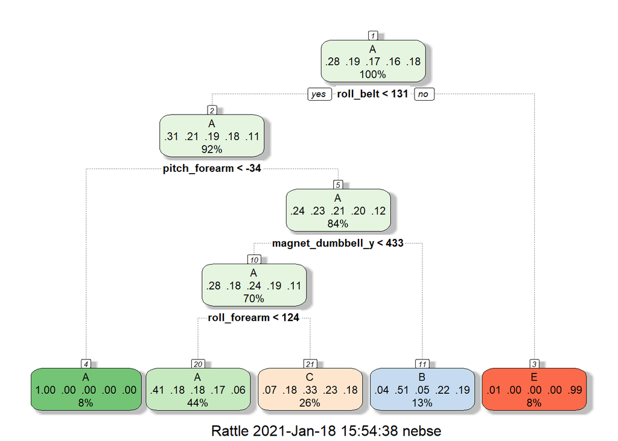

```r
tree_fit <- train(classe ~ .,method="rpart",data=training_cut3,trControl=trainControl(method="cv", number=3, verboseIter=FALSE))

fancyRpartPlot(tree_fit$finalModel)
```

```r
confusionMatrix(testing$classe, predict(tree_fit,testing))
```

```
## Confusion Matrix and Statistics
##
##           Reference
## Prediction    A    B    C    D    E
##          A 1501   35  133    0    5
##          B  467  397  275    0    0
##          C  470   33  523    0    0
##          D  424  193  347    0    0
##          E  144  165  289    0  484
##
## Overall Statistics
##
##                Accuracy : 0.4936
##                  95% CI : (0.4808, 0.5065)
##     No Information Rate : 0.5108
##     P-Value [Acc > NIR] : 0.9959
##
##                   Kappa : 0.3389
##
##  Mcnemar's Test P-Value : NA
##
## Statistics by Class:
##
##                      Class: A Class: B Class: C Class: D Class: E
## Sensitivity            0.4993  0.48238  0.33376       NA  0.98978
## Specificity            0.9399  0.85342  0.88351   0.8362  0.88918
## Pos Pred Value         0.8967  0.34855  0.50975       NA  0.44732
## Neg Pred Value         0.6426  0.91024  0.78514       NA  0.99896
## Prevalence             0.5108  0.13985  0.26627   0.0000  0.08309
## Detection Rate         0.2551  0.06746  0.08887   0.0000  0.08224
## Detection Prevalence   0.2845  0.19354  0.17434   0.1638  0.18386
## Balanced Accuracy      0.7196  0.66790  0.60863       NA  0.93948
```

### ML - tree boosted (gbm)

```r
gbm_fit <- train(classe ~ .,method="gbm",data=training_cut3,trControl=trainControl(method="cv", number=3, verboseIter=FALSE), verbose=FALSE)
confusionMatrix(testing$classe, predict(gbm_fit,testing))
```

```
## Confusion Matrix and Statistics
##
##           Reference
## Prediction    A    B    C    D    E
##          A 1671    2    0    1    0
##          B   12 1120    7    0    0
##          C    0    6 1011    8    1
##          D    1    7   15  940    1
##          E    0    1    3   10 1068
##
## Overall Statistics
##
##                Accuracy : 0.9873
##                  95% CI : (0.9841, 0.99)
##     No Information Rate : 0.2862
##     P-Value [Acc > NIR] : < 2.2e-16
##
##                   Kappa : 0.9839
##
##  Mcnemar's Test P-Value : NA
##
## Statistics by Class:
##
##                      Class: A Class: B Class: C Class: D Class: E
## Sensitivity            0.9923   0.9859   0.9759   0.9802   0.9981
## Specificity            0.9993   0.9960   0.9969   0.9951   0.9971
## Pos Pred Value         0.9982   0.9833   0.9854   0.9751   0.9871
## Neg Pred Value         0.9969   0.9966   0.9949   0.9961   0.9996
## Prevalence             0.2862   0.1930   0.1760   0.1630   0.1818
## Detection Rate         0.2839   0.1903   0.1718   0.1597   0.1815
## Detection Prevalence   0.2845   0.1935   0.1743   0.1638   0.1839
## Balanced Accuracy      0.9958   0.9910   0.9864   0.9877   0.9976
```

### Assessment of ML model types

From the reported accuracy values of these models, it seems clear that **random forest** is the best performing (although the gbm model performed almost as well). Therefore, we will use this model in assessing the final testing set in order to predict the “classe” for each row.

### Quiz Submission - Test set prediction

```r
prediction_quiz <- predict(rf_fit, newdata=data_testing)

classe<-as.matrix(prediction_quiz)
prediction_quiz <- as.factor(prediction_quiz)

quiz_data <- data_testing %>% select(1)
df_quiz <- data.frame(quiz_data, classe)
df_quiz
```

```
##    V1 classe
## 1   1      B
## 2   2      A
## 3   3      B
## 4   4      A
## 5   5      A
## 6   6      E
## 7   7      D
## 8   8      B
## 9   9      A
## 10 10      A
## 11 11      B
## 12 12      C
## 13 13      B
## 14 14      A
## 15 15      E
## 16 16      E
## 17 17      A
## 18 18      B
## 19 19      B
## 20 20      B
```

These are the predictions for each of the datapoints for the requested quiz answers.